# Workshop Preliminaries

# DS

- *Data science* (**DS**): An interdisciplinary field combining math, statistics, programming, and business knowledge to *turn raw, messy data into useful insights*.
- Traditional DS courses provide [**comprehensive** coverage](https://www.udemy.com/course/python-core-and-advanced/) of a programming language (e.g., **Python** or R), building a solid foundation from the ground up
- *Downside*:
  - Overwhelmed by details, students can lose sight of *what matters most* to formulating and implementing a solution to their problem

# Our Strategy

- *One day is too short* for developing the knowledge and know-how comprehensively using the traditional approach
- Instead, this workshop simply
  - showcases some code examples (primarily in **Python**) with which students can *modify and experiment* to turn them into *their own projects* through learn by doing
    - using *AI as a learning and research partner*

# Why Python?

- Python has become the undisputed industry standard due to an *unmatched ecosystem of pre-built tools*
- In late 1990s,
  - the scientific and academic computing communities adopted Python for mathematics and research
- As the “Big Data” and AI boom later took off,
  - researchers naturally built their new machine learning tools on top of the Python code they already knew

## Shell vs GUI

- Code development in Python/R is often done in a *click-and-select* interface, i.e., **graphical user interface** (**GUI**)
- A **shell / terminal** lets you
  - interact with the computing environment using a **command line interface** (**cli**)
- A cli is not as user-friendly as a GUI
  - but can chain code in script files together for *automated/batch processing*

## Jupyter Notebook

- **Jupyter** Notebook/JupyterLab is an industry-standard GUI for *experimenting with and annotating* Python code,
  - combining code, text, and visualizations in a single document
- It has two types of **cells**:
  - **Code** cells contain code that can be executed to produce output (e.g., tables, plots, numerical or textual results)
  - **Markdown** cells contain text formatted using Markdown syntax

## Markdown

- A lightweight markup language for creating formatted text, such as headings, lists, links, and emphasis, using simple *plain-text syntax*
- It is the native language for AI assistants to understand and generate text,
  - making it a natural choice for documenting code and data analysis workflows
- **Quarto**, an industry-standard tool for creating reproducible documents, also uses Markdown to format text
  - e.g., this slidedeck was created with [Quarto using Markdown syntax](https://quarto.org/docs/authoring/markdown-basics.html)

# Story behind Jupyter notebook

- [Embedded in the name](https://blog.jupyter.org/i-python-you-r-we-julia-baf064ca1fb6) **Ju****py**te**r** are letters representing
  - three major data science programming languages:
    - Python, R, and Julia
- [**Julia**](https://julialang.org/), a high-performance language, is a topic for another day
- **R** since its [**tidyverse**](https://tidyverse.org/) era has become very user-friendly for data analysis and visualization

## R vs Python

- **Python**
  - a general-purpose programming language widely used for data analysis and **machine learning** (**ML**)
- **R**
  - a programming language specially designed for **statistical computing** and data analysis
- Their capability can be significantly expanded through importing
  - **libraries** (aka. **packages**) specialized in performing certain functions with commands outside the base language

## R and Python

- Today, the data science related functionalities of the two languages have become very similar
  - Can often find similar libraries for both languages
    - e.g., **dplyr** for R and **pandas** for Python are powerful libraries for working with dataframes
  - Can *call R from Python* using the **rpy2** library
    - can also *call Python from R* using the **reticulate** package

## File formats of code

`myscript` below refers to a script file containing programming code

- **Python**:
  - `.ipynb`: Python code in **Jupyter notebook** format
    - convenient for code development (not for shell use)
  - `.py`: Python code in script format (or marimo notebook as a script)
    - command to execute in shell: `python3 myscript.py`
  - **marimo** notebook offers the *best of both worlds*
- **R**:
  - `.rmd`: R code in **Rmarkdown** notebook format
    - convenient for code development (not for shell use)
  - `.r`: R code in script format
    - command to execute in shell: `Rscript myscript.r`

# Cloud computing platforms

The following platforms have free-tier accounts that let you try Python/R conveniently:

- *GitHub Codespaces* has [**VS Code**](https://code.visualstudio.com/) as its GUI
  - native for **GitHub Copilot**
- [*Posit cloud*](https://posit.cloud/) has [**RStudio**](https://posit.co/download/rstudio-desktop/) (for **R**) as its GUI
  - Can use **GitHub Copilot**
    - but only for inline queries and code generation in the editor

## Why GitHub, GitHub Codespace, and GitHub Copilot?

- **GitHub** provides spaces to *store, manage, and share code* with others
  - Code files of a project are organized in a *repository* (*repo*) with *version control* to track changes
- GitHub **Codespace** (built on **VS Code**) provides a *ready-to-use development environment* in the cloud, without requiring the setup of VS Code in a local machine
- GitHub **Copilot** is an *AI assistant* sitting inside Codespace/VS Code to
  - answer your questions (*Ask* mode)
  - formulate plans to implement your ideas (*Plan* mode)
  - act as your agent to execute the plans to generate code and verify the results (*Agent* mode)

## GitHub ecosystem

[figure not shown]

## GitHub Codespace: Layout

- Centre Panel: **Code editor** area
- Tabs on Left Panel:
  - **Explorer**, Search, Source Control, …, Extensions, …
- Tabs on Bottom Panel:
  - … | **Terminal** | …  
    | Jupyter (visible when a Jupyter notebook is opened) | …
- Right Panel: Chat box for **GitHub Copilot**
  - Mode selection (Agent, **Ask**, Plan)
  - Model selection ( **Auto** only for free-tier)
- Panel toggle buttons (upper right corner)

# Workshop repo on GitHub

- [**TrainingWorkshop**](https://github.com/DrAYim/TrainingWorkshop): Click this to see the repo’s landing page
- A Jupyter notebook in the repo contains code and brief comments to introduce essential Python commands for beginners
- To go through the comments in markdown and execute the code cells,
  - create a **GitHub Codespace** from the repo using the green **Code** button
  - Once ready (i.e., nothing in the Codespace window still spins),
    - find the notebook `prelim2_Jupyter_PythonBasics.ipynb` in the **Explorer** tab on the left panel and click to open the notebook
    - use the **Select Kernel** button (upper right of centre panel) to choose a Python 3.xx kernel
- When hovering over a code cell, you will see an **Execution** button (▶️) appearing on the left side of the cell
  - Click it to execute the code cell and see the output below it

## Things to note

- Be patient as it may take over **12 minutes** to create the Codespace for the first time; subsequent visits require less than 30 seconds to wake it up
  - DON’T start working until the Codespace is ready, or the interruption can result in a **corrupted** Codespace
- *“Do you trust the authors of the files in this folder? Creating a terminal process requires executing code …”* → click **Trust Folder and Continue**
- *“The workspace has tasks (Run setup on open) defined … Do you want to allow automatic tasks to run in all trusted workspaces?”* → click **Allow**
- *“Python completions and type diagnostics are unavailable because …”* → click **Don’t Show Again**
- *“OpenCode: enabled VS Code’s Agents …”* → click **Reload Now**
- *‘Would you like Visual Studio Code to periodically run “git fetch”?’* → click **Yes**

# RStudio project on Posit cloud

- **Project** in Workspace on *Posit cloud*
  - is like **Codespace** on GitHub
- See the shared Project:
  - [**Result_Tables_Using_R**](https://posit.cloud/content/12144701)
- The Rmarkdown notebook `prelim3_ResultTables.Rmd` in the Project contains code to generate the **descriptive statistics, correlation, and regression** tables presented in the second half of this slidedeck
  - The Jupyter notebook `prelim3_ResultTables.ipynb` in the Workshop repo is a Python version of the same code

# Data Analysis Workflow

## Workflow Overview

```
---
config:
  themeVariables:
    fontSize: 9px
---
flowchart LR
C["Data
  Collection"]
  C --> D[Data
  Preparation
  & Cleaning]
  D --> E[Model
  Development]
  E --> F[Analysis
  & Results]
  F --> G[Robustness
  Tests]
  G --> H[Conclusion
  & Implications]

  style C fill:#d4f1f9,stroke:#05386B
  style D fill:#d4f1f9,stroke:#05386B
  style E fill:#d4f1f9,stroke:#05386B
  style F fill:#d4f1f9,stroke:#05386B
  style G fill:#d4f1f9,stroke:#05386B
  style H fill:#d4f1f9,stroke:#05386B
```

## Data Collection Strategy

```
---
config:
  themeVariables:
    fontSize: 9px
---
flowchart LR
    A[Identify Required
    Variables for a
    Research Question] --> B[Map to
    Available
    Data Sources]
    B --> C[Check
    Data
    Availability]
    C --> D{Sufficient
    Coverage?}
    D -- Yes --> E[Extract & Move on]
    D -- No --> F[Modify Research
    Scope/Question]
    F --> A

    style A fill:#e6f7ff,stroke:#0066cc
    style B fill:#e6f7ff,stroke:#0066cc
    style C fill:#e6f7ff,stroke:#0066cc
    style D fill:#ffeecc,stroke:#ff9900
    style E fill:#e6ffe6,stroke:#009900
    style F fill:#ffe6e6,stroke:#cc0000
```

## Data Sources Available at Bayes

| Data Type | Data Source | Content |
| --- | --- | --- |
| Financial | **Compustat** (North America & Global) | Balance sheet, income statement, cash flow data |
| Financial | Capital IQ: Capital Structure | Detailed capital structure information |
| Market | **CRSP** (also, **CRSP-Compustat Merged**) | Stock prices, returns, trading volume |
| Market | Datastream | Global equities, economics, commodities data |
| Banking | Bank Regulatory Database | Bank structure, call reports, holding company financials |
| **…** |  |  |

# Example: Research on ESG and Firm Value

- **Research Question**:
  - *Does superior ESG performance increase firm value for listed companies?*
- **Key Variables**:
  - **Dependent Variable**: **Tobin’s *q*** as a proxy for firm value
  - **Independent Variable**: **ESG score**
  - **Control Variables**: Firm size, leverage, profitability, etc.
- **Sample**:
  - Listed companies from **CRSP-Compustat Merged** database
  - Merged with ESG data in the dataset from Ch. 5 of https://www.greenfinance.education

## Tobin’s *q* and ESG score

- What is **Tobin’s *q***?
- What is **ESG**?

When you do not understand something, **AI is your friend!** (ask [**Claude**](https://claude.ai/new))

## Data Preparation & Cleaning (Before Analysis)

- **Initial assessment**:
  - **Summary statistics** for all variables
  - **Missing data** patterns and outlier identification
- **Common cleaning procedures**:
  - Outlier treatment:
    - e.g., **winsorization**: Typically at 1% and 99%
  - Variable transformation:
    - e.g., **logarithmic** (`log`): Turn a skewed distribution close to normally distributed

## Model Development Example: Regression Models

- **Pooled OLS regression**:
  - Basic approach combining *cross-sectional and time-series* data
  - Example:  
    $q_{i,t} = \alpha + \beta_1 ESGscore_{i,t} + \beta_2 Controls_{i,t} + \varepsilon_{i,t}$
- **Year and industry indicators**:
  - Control for *time trends and industry differences*
  - e.g., $q_{i,t} = \alpha + \beta_1 ESGscore_{i,t} + \beta_2 Controls_{i,t}$  
    $+ \beta_3 \sum Year_t + \beta_4 \sum Industry_i + \varepsilon_{i,t}$

## What are year and industry indicators used in regression?

- Ask [**Gemini**](https://gemini.google.com/)!

# Analysis & Results Example: Descriptive statistics table

| Variable | N | Mean | Median | Std. Dev. | Min | Max |
| --- | --- | --- | --- | --- | --- | --- |
| *q* | 4,200 | 1.82 | 1.56 | 0.94 | 0.78 | 4.65 |
| ESGscore | 4,200 | 65.34 | 67.00 | 18.45 | 12.00 | 95.00 |
| Firm_Size | 4,200 | 8.45 | 8.32 | 1.75 | 4.62 | 12.85 |
| Leverage | 4,200 | 0.42 | 0.39 | 0.21 | 0.04 | 0.93 |

## Descriptive statistics table

- *How to produce the descriptive statistics table in the attached screenshot (using Python)?*
  - Ask [**Qwen**](https://chat.qwen.ai/) (after uploading the screenshot below)!

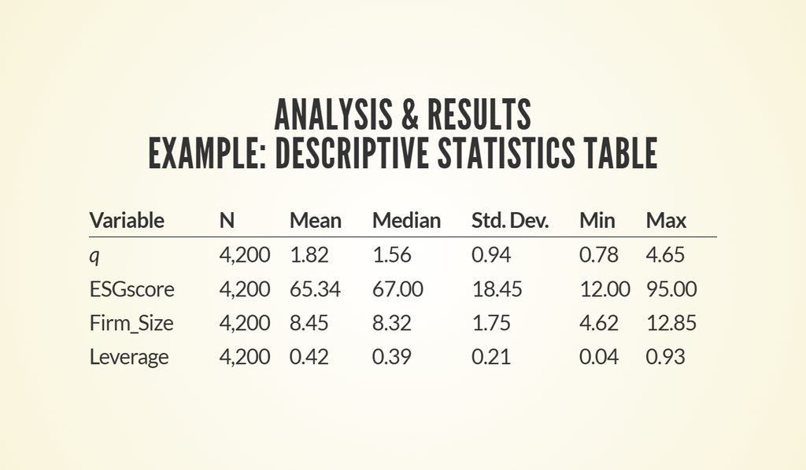

## Analysis & Results Example: Correlation table

|  | *q* | ESGscore | Firm_Size | Leverage |
| --- | --- | --- | --- | --- |
| *q* | 1.000 |  |  |  |
| ESGscore | 0.285*** | 1.000 |  |  |
| Firm_Size | 0.124** | 0.356*** | 1.000 |  |
| Leverage | -0.142** | 0.034 | 0.289*** | 1.000 |

• *Note*: *** p<0.01, ** p<0.05, * p<0.1

## Correlation table

- *How to produce the correlation table in the attached screenshot (using Python)?*
  - Ask [**Grok Fast**](https://grok.com/) (after uploading the screenshot below)!

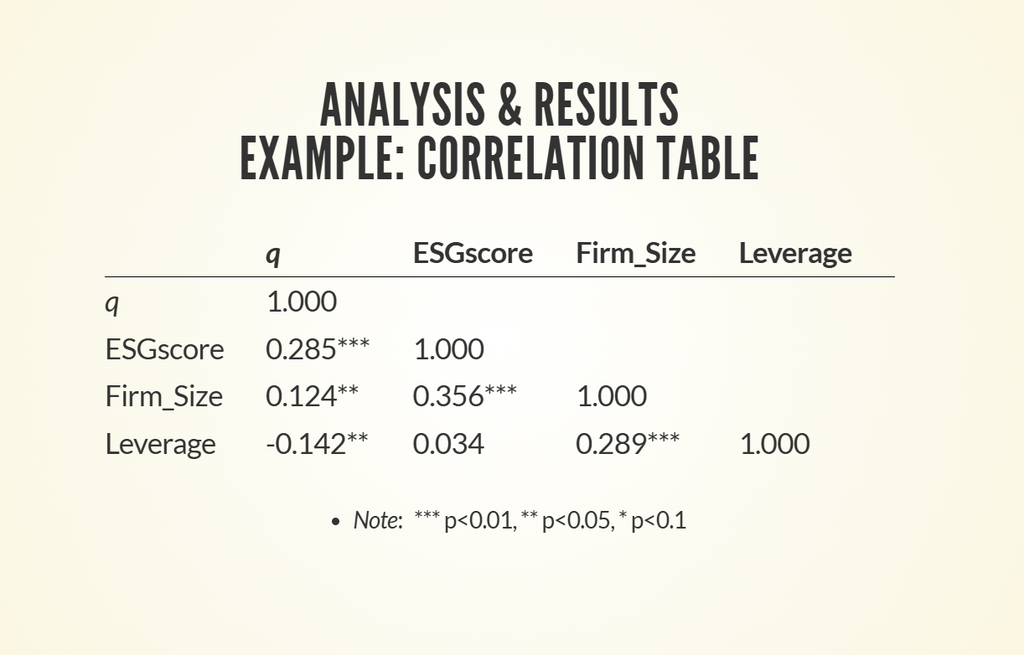

## Analysis & Results Example: Regression table

[output not shown]

• *Note*: Standard errors in parentheses; *** p<0.01, ** p<0.05, * p<0.1

## Analysis & Results Example: Robustness Checks

| Variable | Main Results | Alternative ESG Measure | Subsample: Large Firms | Subsample: 2010-2019 |
| --- | --- | --- | --- | --- |
| ESGscore | 0.021*** | 0.018** | 0.025*** | 0.019** |
|  | (0.007) | (0.008) | (0.009) | (0.008) |
| Controls | Yes | Yes | Yes | Yes |
| Industry Indicators | Yes | Yes | Yes | Yes |
| Year Indicators | Yes | Yes | Yes | Yes |
| Observations | 4,200 | 4,050 | 2,340 | 2,100 |
| R-squared | 0.337 | 0.328 | 0.356 | 0.342 |

• *Note*: Standard errors in parentheses; *** p<0.01, ** p<0.05, * p<0.1

# Thank you

- See you at the Workshop!